# Autostart

We need to figure out auto-start method…

```r
library("fitsir")

bombay2 <- setNames(bombay, c("tvec", "count"))
```

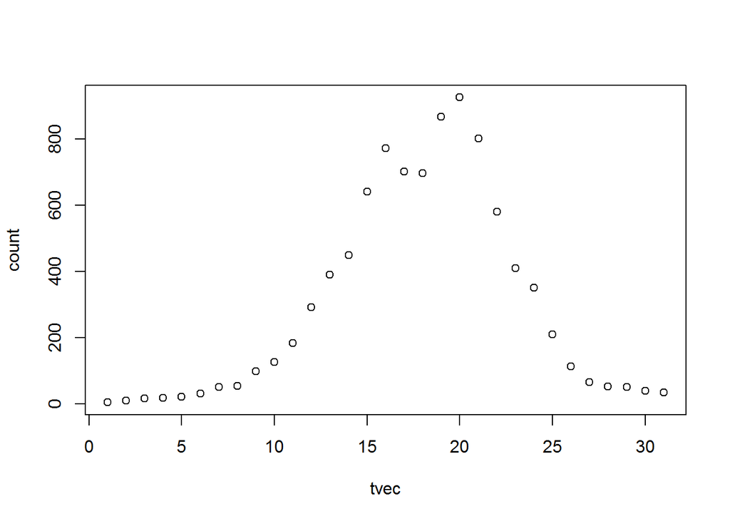

```r
plot(bombay2)
```

I’m going to try doing things mostly based on the spline fit.

```r
tvec <- bombay2$tvec
count <- bombay2$count

ncrit <- Inf
it <- 1
spar <- 0.5
while (ncrit>1 && it<10) {
    ss <- smooth.spline(tvec,log(count),spar=spar)
  dd <- predict(ss,deriv=1)$y
    ncrit <- sum(diff(sign(dd))!=0)
    spar <- (1+spar)/2
}
if (it==10) stop("couldn't smooth enough")

ss.data <- data.frame(tvec = tvec, count = exp(predict(ss)$y))
```

We know $r = \beta - \gamma$,,,

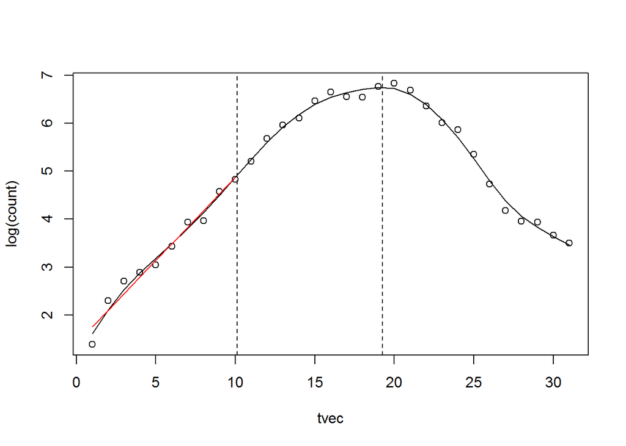

```r
plot(tvec,log(count))
lines(predict(ss))

## find max value
ss.tmax <- uniroot(function(x) predict(ss,x,deriv=1)$y,range(tvec))$root

## find a point halfway between initial and max
##  scaling could be adjustable?
ss.thalf <- min(tvec)+0.5*(ss.tmax-min(tvec))

abline(v = ss.tmax, lty = 2)
abline(v = ss.thalf, lty = 2)

m1 <- lm(log(count)~tvec,data=subset(ss.data,tvec<ss.thalf))

r <- as.numeric(coef(m1)[2]) ##beta - gamma

lines(predict(m1), col = 2)
```

We also know that $I(0) = N i_0$

```r
iniI <- ss.data$count[1] ## N * i0
```

This equation is still valid: $-\frac{Q_p}{I_p} = \frac{\beta \gamma}{N}$

```r
## curvature of spline at max

Qp.alt <- predict(ss,ss.tmax,deriv=2)$y
Ip <- exp(max(predict(ss,tvec)$y))
c <- -Qp.alt/Ip
```

Can we assume that $N = S + I$ and say that $\frac{\gamma N}{\beta} = N - I_p$? This is probably as bad as the previous assumption but this shouldn’t give us negative parameters at least… Probably more stable…

$\begin{aligned} \frac{\gamma N}{\beta} &= N - I_p\\ I_p &= N (1 - \frac{\gamma}{\beta})\\ I_p &= - \beta \gamma \frac{I_p}{Q_p} (1 - \frac{\gamma}{\beta})\\ -Q_p/r &= \gamma\\ \end{aligned}$

```r
gamma = -Qp.alt/r
beta = gamma + r
N = beta * gamma/c
i0 = iniI/N

auto.pars <- c(
  log.beta = log(beta),
  log.gamma = log(gamma),
  log.N = log(N),
  logit.i = qlogis(i0)
)

source("../R/fitSIR_funs.R")
library(deSolve)
```

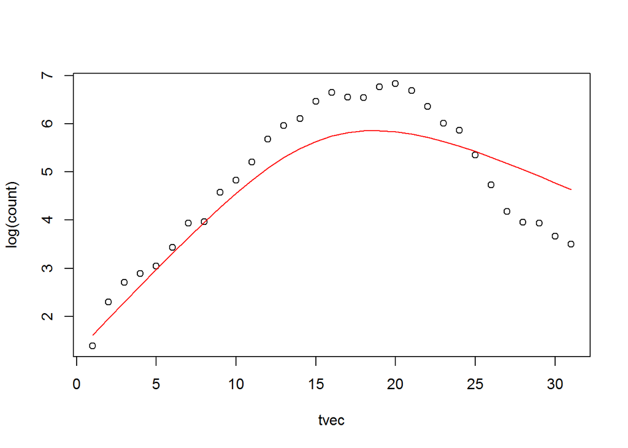

```r
I <- SIR.detsim(tvec, auto.pars)

plot(tvec,log(count))
lines(log(I),col = 2)
```

### Incidence

I’m going to make up the data…

```r
rm(list = ls())
source("../R/fitSIR_funs.R")
library(deSolve)

pars <- c(
  beta = 0.7,
  gamma = 0.2,
  N = 5000,
  i0 = 0.01
)

tvec <- seq(1, 30, 0.1)

count <- SIR.detsim(tvec, pars, incidence = TRUE)
```

```r
ncrit <- Inf
it <- 1
spar <- 0.5
while (ncrit>1 && it<10) {
  ss <- smooth.spline(tvec,log(count),spar=spar)
  dd <- predict(ss,deriv=1)$y
    ncrit <- sum(diff(sign(dd))!=0)
    spar <- (1+spar)/2
}
if (it==10) stop("couldn't smooth enough")

ss.data <- data.frame(tvec = tvec, count = exp(predict(ss)$y))
```

We know that $I = \beta S P/N$. In the initial phase of epidemic, $S \approx N$ so we have $\log I = \log(\beta) + \log P$. We also know that $\log P$ grows at a rate $r$. So the slope of $\log I$ is also $r$.

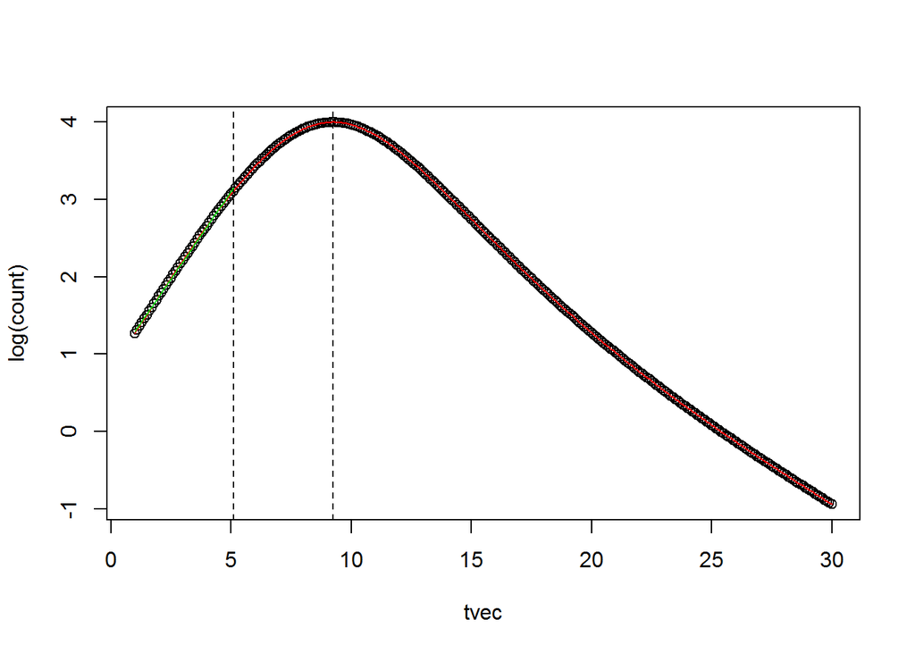

```r
plot(tvec,log(count))
lines(tvec,log(ss.data$count), col = 2)

## find max value
ss.tmax <- uniroot(function(x) predict(ss,x,deriv=1)$y,range(tvec))$root

## find a point halfway between initial and max
##  scaling could be adjustable?
ss.thalf <- min(tvec)+0.5*(ss.tmax-min(tvec))

abline(v = ss.tmax, lty = 2)
abline(v = ss.thalf, lty = 2)

thalf.range <- which(tvec < ss.thalf)

m1 <- lm(log(count)~tvec,data=ss.data[thalf.range,])

r <- as.numeric(coef(m1)[2]) ##beta - gamma

lines(tvec[thalf.range], predict(m1), col = 3)
```

We also know that $I(1)/(t_2 - t_1) = \beta N (1-i0) i0$

```r
count[1]/(tvec[2] - tvec[1])
```

```
## [1] 35.51222
```

```r
0.7 * 5000 * (1 - 0.01) * 0.01
```

```
## [1] 34.65
```

```r
##Seems like it works
```

If the data is large enough, we’re going to have $\int I(t) dt \approx N$

```r
N = cumsum(count)[length(tvec)]
```

We can convert incidence into prevalence by using the following equation: $P \approx I\Delta t/\gamma$. This is the equation we want to use: $-\frac{Q_p}{P_p} = \frac{\beta \gamma}{N}$.

We can do this $P_p = \max(I\Delta t/\gamma) = \max(I\Delta t)/\gamma$. $Q_p$ can be also calculated by taking the second derivative of $I\Delta t$ and multiplying $1/\gamma$. Therefore, $Q_p/P_p$ ratio can be calculated without knowing $\gamma$.

```r
t.diff <- diff(tvec)
t.diff <- c(t.diff[1], t.diff)

P <- ss.data$count/t.diff

ncrit <- Inf
it <- 1
spar <- 0.5
while (ncrit>1 && it<10) {
  ss.P <- smooth.spline(tvec,log(P),spar=spar)
  dd <- predict(ss.P,deriv=1)$y
  ncrit <- sum(diff(sign(dd))!=0)
    spar <- (1+spar)/2
}

ss.P.tmax <- uniroot(function(x) predict(ss.P,x,deriv=1)$y,range(tvec))$root

Qp.alt <- predict(ss.P,ss.P.tmax,deriv=2)$y
Ip <- exp(max(predict(ss.P,tvec)$y))

c = -Qp.alt/Ip
```

Now, we can get all four parameters.

First, we can use $\beta \gamma = N \frac{-Q_p}{P_p}$ and $\beta - \gamma = r$:

$\begin{aligned} \gamma^2 + r \gamma - N c = 0 \end{aligned}$

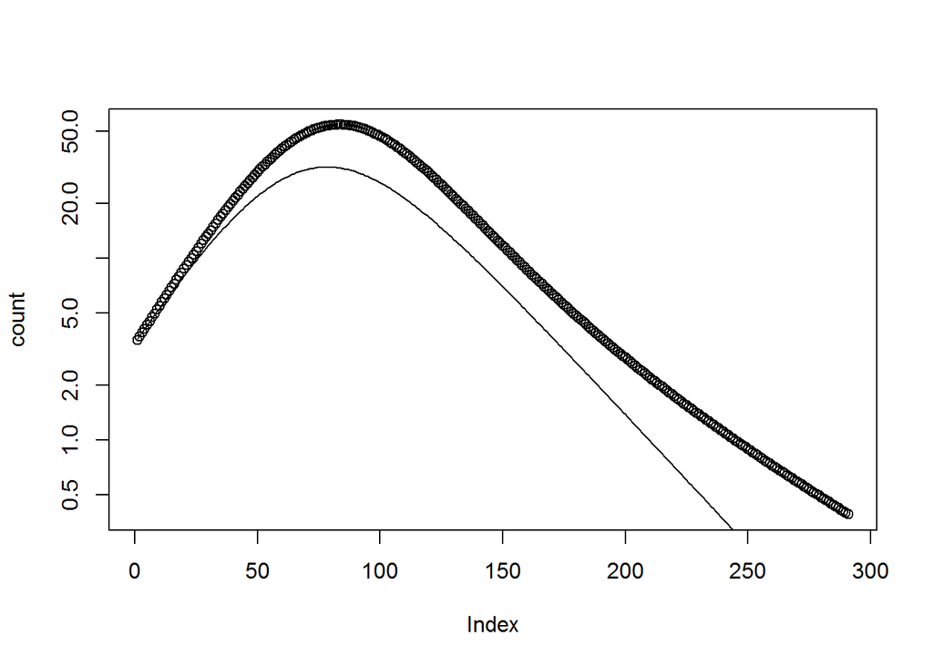

```r
gamma = 0.5 * (sqrt(4*c*N + r^2)-r)

beta = gamma + r

N = N

d = count[1]/(t.diff[1]* beta * N)

i0 = 0.5 * (1-sqrt(1-4*d))

pars.auto = c(
  beta=beta,
  gamma=gamma,
  N=N,
  i0 = i0
)

count2 <- SIR.detsim(tvec, pars.auto, incidence= TRUE)

plot(count, log = "y")
lines(count2)
```

Here’s the auto-start code:

```r
pars <- c(
  beta = 0.8,
  gamma = 0.4,
  N = 50000,
  i0 = 0.02
)

tvec <- seq(1, 30, 0.1)

count <- SIR.detsim(tvec, pars, incidence = TRUE)

(pars.auto2 <- trans.pars(startfun(data = data.frame(tvec = tvec, count = count), auto = TRUE, incidence = TRUE)))
```

```
## $beta
## [1] 1.048602
##
## $gamma
## [1] 0.7289968
##
## $N
## [1] 39064.6
##
## $i0
## [1] 0.01994128
```

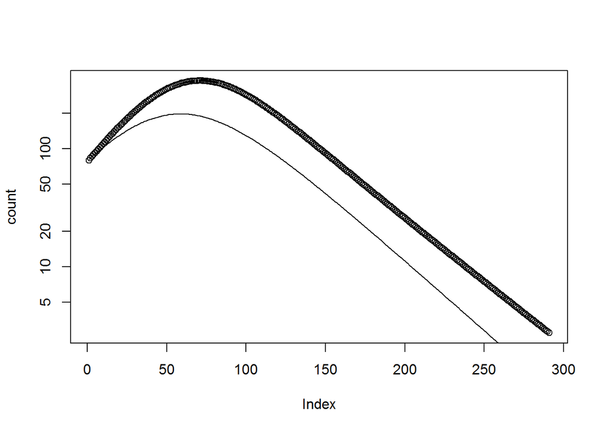

```r
count2 <- SIR.detsim(tvec, pars.auto2, incidence= TRUE)

plot(count, log = "y")
lines(count2)
```